[O’Hara on GitHub](https://github.com/oharac)

# Compare cumulative impacts per species to IUCN status

Compiled on Mon Apr 11 11:10:33 2022 by ohara

```r
knitr::opts_chunk$set(echo = TRUE, message = FALSE, warning = FALSE)

library(raster)
library(tidyverse)
library(here)
library(RColorBrewer)
library(oharac)
library(caret)
source(here('common_fxns.R'))
```

# 1 Summary

Calculate the cumulative impact across each species range (total and coastal-only). Relative CHI will be the total CHI (summed across all cells and all stressors) normalized by the total range (total and coastal-only). The relative CHI is effectively the average CHI per km<sup>2</sup> across the species’ range.

Perform a regression of IUCN extinction risk classification as a function of relative overall CHI and overall range, and then do the same for coastal.

# 2 Data

- Species impact scores from script 6
- IUCN extinction risk scores from IUCN

# 3 Methods

## 3.1 Read in species impacts for those spp assessed by IUCN; summarize to CHI

Summarize to cumulative impacts by entire range and by coastal range.

Each file has a row for each stressor-vulnerability match; columns are:

- `str_vuln` (chr): name of stressor/vuln combo, as -
- `impact_tot` (dbl): sum across all cells of stressor intensity $\times$ vulnerability $\times$ ocean area
- `impact_coastal` (dbl): sum across all coastal cells (≤200m) of stressor intensity $\times$ vulnerability $\times$ ocean area
- `range_tot_km2` (dbl): sum of ocean area of all cells across entire range
- `range_coastal_km2` (dbl): sum of ocean area of all cells across coastal range

```r
spp_chi_file <- here_anx('int/spp_chi_summary.csv')

if(!file.exists(spp_chi_file)) { ### unlink(spp_chi_file)
  spp_imp_fs <- list.files(here_anx('impacts_by_species'),
                           pattern = '^impacts_.+.csv', full.names = TRUE)

  spp_imp_raw_df <- parallel::mclapply(spp_imp_fs, mc.cores = 40,
                                       data.table::fread) %>%
    setNames(basename(spp_imp_fs)) %>%
    data.table::rbindlist(idcol = 'f')

  spp_ranges <- spp_imp_raw_df %>%
    select(f, range_km2, range) %>%
    distinct() %>%
    spread(range, range_km2) %>%
    rename(range_cst_km2 = coastal, range_tot_km2 = full)

  spp_intensity_df <- spp_imp_raw_df %>%
    select(f, vuln, stressor, intensity_tot, range) %>%
    spread(range, intensity_tot) %>%
    rename(intensity_tot = full, intensity_cst = coastal)

  spp_intens_cv_df <- spp_imp_raw_df %>%
    select(f, vuln, stressor, intensity_cv, range) %>%
    spread(range, intensity_cv) %>%
    rename(intensity_cv_tot = full, intensity_cv_cst = coastal)

  spp_impacts_df <- spp_imp_raw_df %>%
    select(f, vuln, stressor, impact_tot, range) %>%
    spread(range, impact_tot) %>%
    rename(impact_tot = full, impact_cst = coastal)

  spp_cv_df <- spp_imp_raw_df %>%
    select(f, vuln, stressor, impact_cv, range) %>%
    spread(range, impact_cv) %>%
    rename(impact_cv_tot = full, impact_cv_cst = coastal)

  spp_impacts_npp_df <- spp_imp_raw_df %>%
    select(f, vuln, stressor, impact_npp_tot, range) %>%
    spread(range, impact_npp_tot) %>%
    rename(impact_npp_tot = full, impact_npp_cst = coastal)

  spp_npp_cv_df <- spp_imp_raw_df %>%
    select(f, vuln, stressor, impact_npp_cv, range) %>%
    spread(range, impact_npp_cv) %>%
    rename(impact_npp_cv_tot = full, impact_npp_cv_cst = coastal)

  iucn_worms_lookup <- read_csv(here('_data/iucn_spp', 'iucn_to_worms_match.csv'))

  spp_imp_cv_df <- full_join(spp_impacts_df, spp_cv_df,
                             by = c('f', 'vuln', 'stressor')) %>%
    full_join(spp_impacts_npp_df, by = c('f', 'vuln', 'stressor')) %>%
    full_join(spp_npp_cv_df, by = c('f', 'vuln', 'stressor')) %>%
    full_join(spp_intensity_df, by = c('f', 'vuln', 'stressor')) %>%
    full_join(spp_intens_cv_df, by = c('f', 'vuln', 'stressor')) %>%
    left_join(spp_ranges, by = 'f') %>%
    ### extract species and map info from filename
    mutate(map_src = str_extract(f, '_iucn_|_am_') %>% str_remove_all('_'),
           iucn_sid = str_extract(f, '[0-9]+') %>% as.integer(),
           spp_from_f = str_remove_all(f, 'impacts_(am|iucn)_|.csv')) %>%
    left_join(iucn_worms_lookup, by = 'iucn_sid') %>%
    mutate(sciname = ifelse(is.na(worms_name),
                            str_replace_all(spp_from_f, '_', ' '),
                            worms_name)) %>%
    ### append iucn_sid for spp not mapped in IUCN but mapped in AM:
    left_join(iucn_worms_lookup %>% select(sciname = worms_name, iucn_sid2 = iucn_sid),
              by = c('sciname')) %>%
    mutate(iucn_sid = ifelse(is.na(iucn_sid), iucn_sid2, iucn_sid)) %>%
    select(sciname, iucn_sid, map_src, vuln, stressor,
           impact_cst, impact_tot, impact_cv_cst, impact_cv_tot,
           impact_npp_cst, impact_npp_tot,
           impact_npp_cv_cst, impact_npp_cv_tot,
           intensity_cst, intensity_tot,
           intensity_cv_cst, intensity_cv_tot,
           range_cst_km2, range_tot_km2) %>%
    distinct() %>%
    filter(range_tot_km2 > 0 & !is.na(impact_tot))

  write_csv(spp_imp_cv_df, spp_chi_file)
}
```

### 3.1.1 Assemble IUCN Red List categories for species in IUCN maps and AquaMaps maps

```r
iucn_worms_lookup <- read_csv(here('_data/iucn_spp', 'iucn_to_worms_match.csv'),
                              show_col_types = FALSE)

iucn_assessed <- read_csv(here('_data/iucn_spp/iucn_marine_spp_info_2021-3.csv'),
                              show_col_types = FALSE) %>%
  select(iucn_sid, cat, cat_score) %>%
  left_join(iucn_worms_lookup, by = 'iucn_sid') %>%
  mutate(threatened = case_when(cat == 'dd' ~ NA,
                                cat %in% c('lc', 'nt') ~ FALSE,
                                TRUE ~ TRUE),
         atrisk     = case_when(cat == 'dd' ~ NA,
                                cat %in% c('lc') ~ FALSE,
                                TRUE ~ TRUE)) %>%
  select(iucn_sid, iucn_sciname = sciname, sciname = worms_name,
         cat, cat_score, threatened, atrisk)
```

### 3.1.2 Combine IUCN categories with impacts

```r
iucn_impacts_df <- read_csv(spp_chi_file,
                            show_col_types = FALSE) %>%
  inner_join(iucn_assessed, by = c('sciname', 'iucn_sid')) %>%
  mutate(iucn_fct = toupper(cat),
         iucn_fct = factor(iucn_fct, levels = c('LC', 'NT', 'VU', 'EN', 'CR', 'EX', 'DD')))

check_df <- iucn_impacts_df %>%
  select(sciname, iucn_sid, map_src) %>%
  distinct() %>%
  janitor::get_dupes(sciname)

spp_taxa <- assemble_worms() %>%
  select(sciname = species, phylum, class, order, family) %>%
  distinct() %>%
  inner_join(get_spp_vuln() %>%
             select(sciname = species, taxon) %>%
             distinct())

fished_spp <- iucn_impacts_df %>%
  filter(stressor == 'biomass_removal') %>%
  mutate(fished = impact_cst > 0 | impact_tot > 0) %>%
  select(sciname, iucn_sid, fished)

spp_chi_iucn_clean <- iucn_impacts_df %>%
  filter(stressor == 'cumulative') %>%
  mutate(chi_rel_tot = impact_tot / range_tot_km2,
         chi_rel_cst = impact_cst / range_cst_km2,
         chi_npp_tot = impact_npp_tot / range_tot_km2,
         chi_npp_cst = impact_npp_cst / range_cst_km2) %>%
  filter(!is.na(threatened)) %>%
  left_join(spp_taxa, by = 'sciname') %>%
  left_join(fished_spp, by = c('sciname', 'iucn_sid'))
```

## 3.2 Try some simple tests

### 3.2.1 examine CHI by range

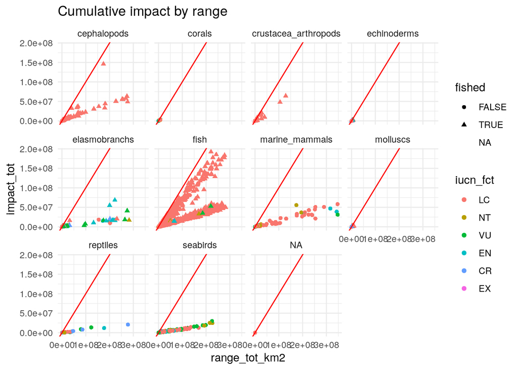

```r
ggplot(spp_chi_iucn_clean, aes(x = range_tot_km2, y = impact_tot)) +
  geom_point(aes(color = iucn_fct, shape = fished)) +
  geom_abline(slope = 1, intercept = 0, color = 'red', size = .5) +
  # scale_y_log10() +
  theme_minimal() +
  facet_wrap(~ taxon) +
  labs(title = 'Cumulative impact by range')
```

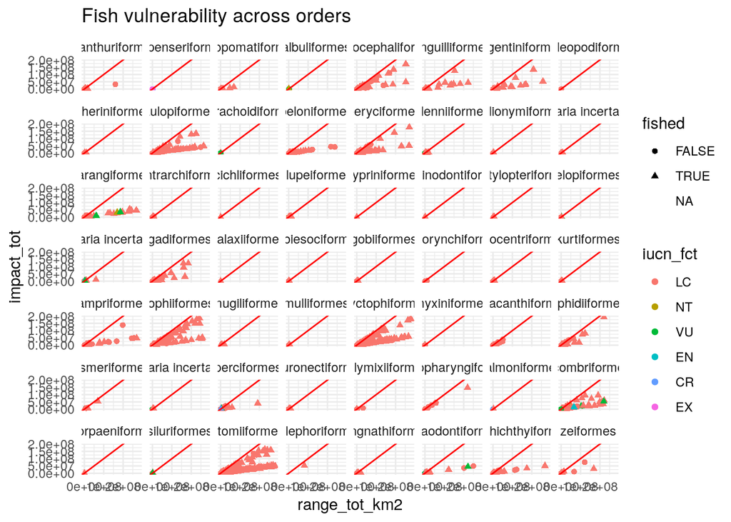

```r
ggplot(spp_chi_iucn_clean %>% filter(taxon == 'fish'),
       aes(x = range_tot_km2, y = impact_tot)) +
  geom_point(aes(color = iucn_fct, shape = fished)) +
  geom_abline(slope = 1, intercept = 0, color = 'red', size = .5) +
  # scale_y_log10() +
  theme_minimal() +
  facet_wrap(~ order) +
  labs(title = 'Fish vulnerability across orders')
```

Technically possible for species to have higher total impacts than range, e.g., if high vulnerability (near 1) to multiple very intense stressor (near 1) across most of its range.

Questions:

- Are the spp near the 1:1 line due to cumulative effects, or dominated by a single stressor?
- there seem to be a few “clusters” of slopes, notably two distinct clusters in fish.

#### 3.2.1.1 examine potential vulnerability clusters

Perhaps the clusters relate to two distinct groupings of vulnerability. Focusing on fish, examine distribution of vulnerability across all included stressors.

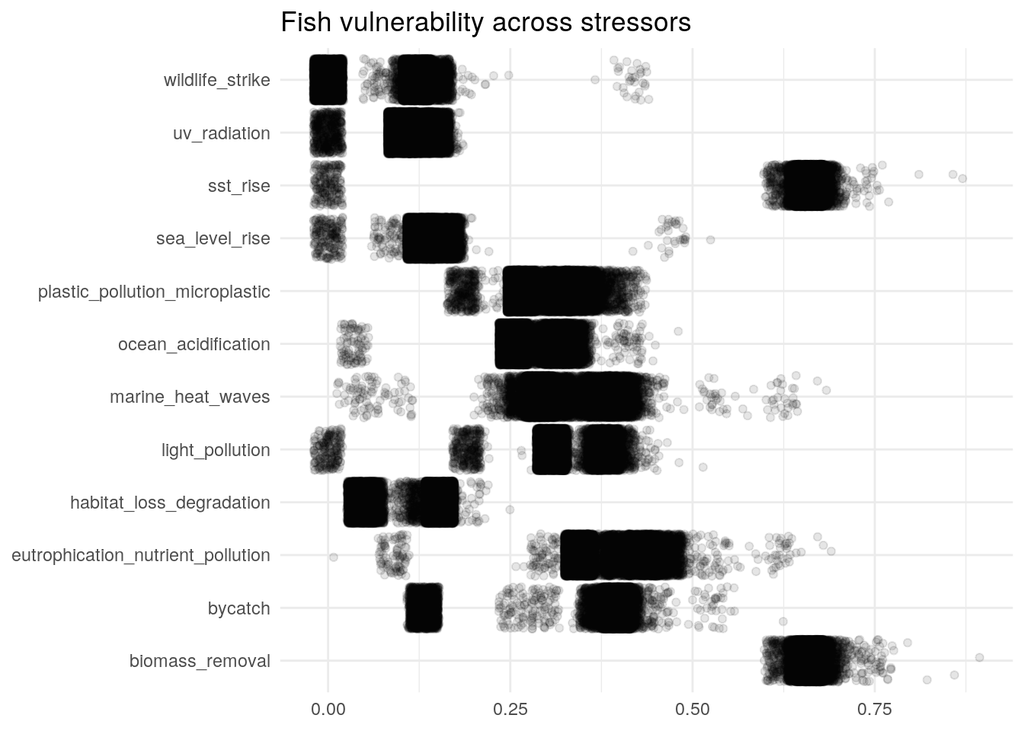

```r
vuln_in_chi <- iucn_impacts_df$vuln %>% unique()
fish_vuln_in_chi <- get_spp_vuln() %>%
  filter(taxon == 'fish' & stressor %in% vuln_in_chi)

ggplot(fish_vuln_in_chi, aes(y = stressor, x = score)) +
  geom_jitter(width = 0.02, alpha = .1) +
  theme_minimal() +
  theme(axis.title = element_blank()) +
  labs(title = 'Fish vulnerability across stressors')
```

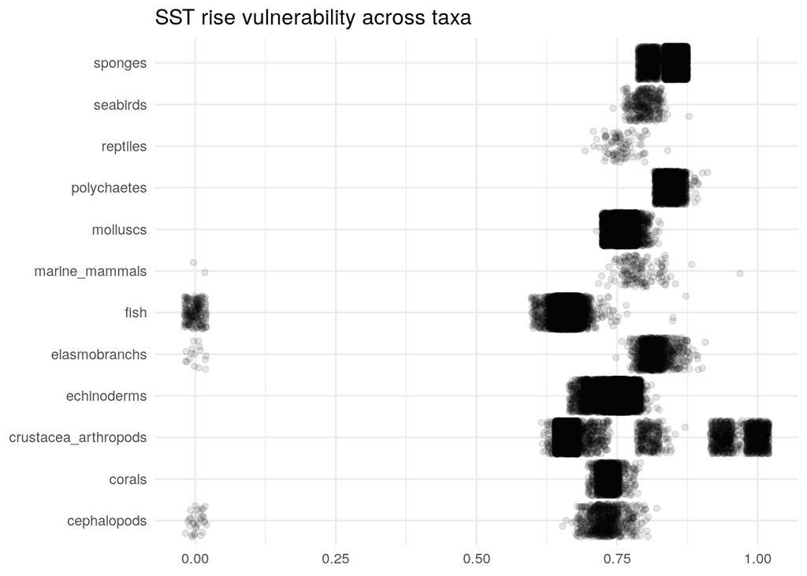

```r
sst_rise_vuln_in_chi <- get_spp_vuln() %>%
  filter(stressor == 'sst_rise')

ggplot(sst_rise_vuln_in_chi, aes(y = taxon, x = score)) +
  geom_jitter(width = 0.02, alpha = .1) +
  theme_minimal() +
  theme(axis.title = element_blank()) +
  labs(title = 'SST rise vulnerability across taxa')
```

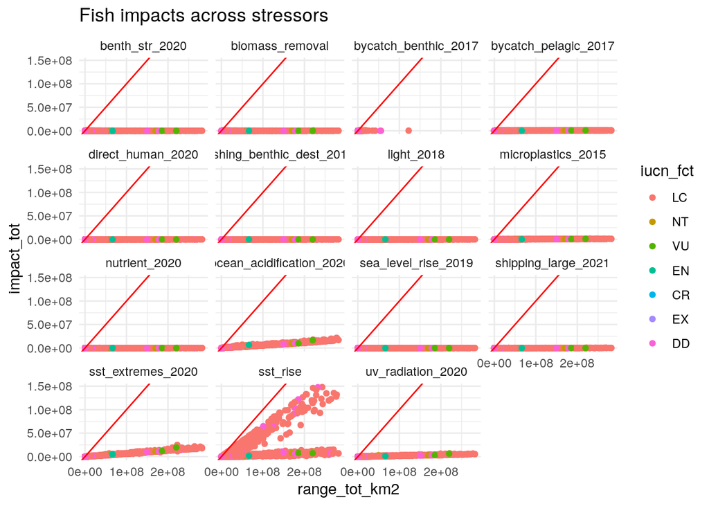

```r
fish_impacts_df <- iucn_impacts_df %>%
  left_join(get_spp_vuln(), by = c('sciname' = 'species', 'vuln' = 'stressor')) %>%
  filter(taxon == 'fish')

ggplot(fish_impacts_df,
       aes(x = range_tot_km2, y = impact_tot)) +
  geom_point(aes(color = iucn_fct)) +
  geom_abline(slope = 1, intercept = 0, color = 'red', size = .5) +
  # scale_y_log10() +
  theme_minimal() +
  facet_wrap(~ stressor) +
  labs(title = 'Fish impacts across stressors')
```

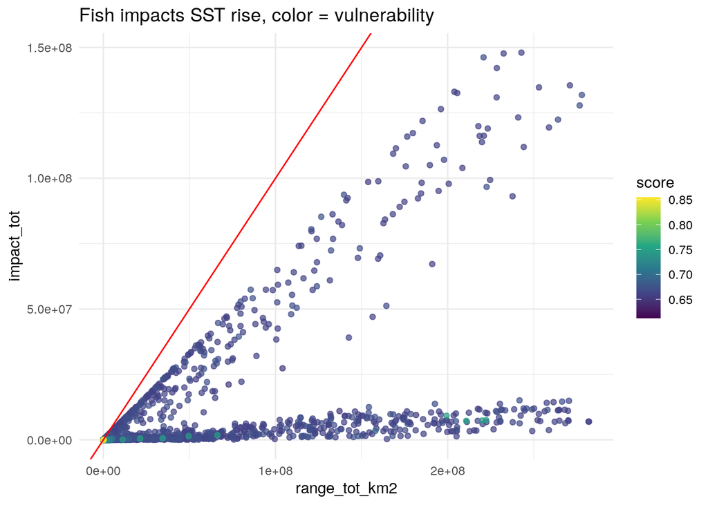

```r
ggplot(fish_impacts_df %>%
         filter(vuln == 'sst_rise') %>%
         arrange(score),
       aes(x = range_tot_km2, y = impact_tot)) +
  geom_point(aes(color = score), alpha = .7) +
  scale_color_viridis_c() +
  geom_abline(slope = 1, intercept = 0, color = 'red', size = .5) +
  # scale_y_log10() +
  theme_minimal() +
  labs(title = 'Fish impacts SST rise, color = vulnerability')
```

From this it appears that the bifurcated impact plots are due to different levels of exposure to SST rise, rather than differential vulnerability to SST rise. This in turn may be due to geographic location - the spp with high SST impacts may be all in the same ocean basin, or similar latitudes, etc.

## 3.3 Binomial logistic regression - CHI

Perform a binomial logistic regression of threatened status (threatened/not threatened) as a function of mean cumulative impact and range. Set up data frame to include a `threatened` column, where LC and NT are `FALSE` and VU, EN, and CR are `TRUE`. Include range as inverse log of range, for both overall range and coastal-only range.

### 3.3.1 Prob of threatened = TRUE as function of CHI and range

```r
chi_threatened_valid <- spp_chi_iucn_clean %>%
  filter(!is.na(threatened)) %>%
  mutate(inv_log_r_tot  = 1/log(range_tot_km2),
         inv_log_r_cst  = 1/log(range_cst_km2),
         inv_sqrt_r_tot = 1/sqrt(range_tot_km2),
         inv_sqrt_r_cst = 1/sqrt(range_cst_km2))
```

```r
df_for_blr <- chi_threatened_valid %>%
  select(sciname, taxon, phylum, class, atrisk, threatened,
         starts_with('impact'), starts_with('chi'),
         starts_with('inv_log'), starts_with('range')) %>%
  mutate(qtile_r = ntile(range_tot_km2, n = 5))

df_for_blr %>% group_by(qtile_r) %>% summarize(r = max(range_tot_km2))
```

```
## # A tibble: 5 × 2
##   qtile_r          r
##     <int>      <dbl>
## 1       1    148899
## 2       2    532494
## 3       3   1647099
## 4       4   4912120.
## 5       5 347400858.
```

```r
### across all spp, coastal ranges
mdl1 <- glm(threatened ~ chi_npp_cst + impact_npp_cv_cst + inv_log_r_cst,
           data = df_for_blr,
           family = 'binomial')
summary(mdl1)
```

```
##
## Call:
## glm(formula = threatened ~ chi_npp_cst + impact_npp_cv_cst +
##     inv_log_r_cst, family = "binomial", data = df_for_blr)
##
## Deviance Residuals:
##     Min       1Q   Median       3Q      Max
## -1.3253  -0.4785  -0.4438  -0.4160   2.2802
##
## Coefficients:
##                   Estimate Std. Error z value Pr(>|z|)
## (Intercept)       -3.80593    0.17887 -21.278  < 2e-16 ***
## chi_npp_cst        0.09621    0.13566   0.709 0.478183
## impact_npp_cv_cst  0.14504    0.04262   3.403 0.000666 ***
## inv_log_r_cst     15.10531    1.25011  12.083  < 2e-16 ***
## ---
## Signif. codes:  0 '***' 0.001 '**' 0.01 '*' 0.05 '.' 0.1 ' ' 1
##
## (Dispersion parameter for binomial family taken to be 1)
##
##     Null deviance: 7451.2  on 10965  degrees of freedom
## Residual deviance: 7314.8  on 10962  degrees of freedom
##   (30 observations deleted due to missingness)
## AIC: 7322.8
##
## Number of Fisher Scoring iterations: 5
```

```r
### filter for smaller-ranged spp, coastal ranges
mdl2 <- glm(threatened ~ chi_npp_cst + impact_npp_cv_cst + inv_log_r_cst,
           data = df_for_blr %>% filter(qtile_r == 1),
           family = 'binomial')
summary(mdl2)
```

```
##
## Call:
## glm(formula = threatened ~ chi_npp_cst + impact_npp_cv_cst +
##     inv_log_r_cst, family = "binomial", data = df_for_blr %>%
##     filter(qtile_r == 1))
##
## Deviance Residuals:
##     Min       1Q   Median       3Q      Max
## -1.3820  -0.6283  -0.5743  -0.4867   2.6479
##
## Coefficients:
##                   Estimate Std. Error z value Pr(>|z|)
## (Intercept)       -1.88529    0.36201  -5.208 1.91e-07 ***
## chi_npp_cst        0.30748    0.19344   1.589 0.111948
## impact_npp_cv_cst -0.31388    0.08405  -3.734 0.000188 ***
## inv_log_r_cst     10.76033    1.90387   5.652 1.59e-08 ***
## ---
## Signif. codes:  0 '***' 0.001 '**' 0.01 '*' 0.05 '.' 0.1 ' ' 1
##
## (Dispersion parameter for binomial family taken to be 1)
##
##     Null deviance: 2043.7  on 2176  degrees of freedom
## Residual deviance: 1976.6  on 2173  degrees of freedom
##   (23 observations deleted due to missingness)
## AIC: 1984.6
##
## Number of Fisher Scoring iterations: 4
```

```r
### similar but total ranges
mdl3 <- glm(threatened ~ chi_npp_tot + impact_npp_cv_tot + inv_log_r_tot,
           data = df_for_blr %>% filter(qtile_r == 1),
           family = 'binomial')
summary(mdl3)
```

```
##
## Call:
## glm(formula = threatened ~ chi_npp_tot + impact_npp_cv_tot +
##     inv_log_r_tot, family = "binomial", data = df_for_blr %>%
##     filter(qtile_r == 1))
##
## Deviance Residuals:
##     Min       1Q   Median       3Q      Max
## -1.5377  -0.6203  -0.5666  -0.4811   2.6261
##
## Coefficients:
##                   Estimate Std. Error z value Pr(>|z|)
## (Intercept)       -2.25769    0.37218  -6.066 1.31e-09 ***
## chi_npp_tot        0.34933    0.19884   1.757 0.078943 .
## impact_npp_cv_tot -0.26962    0.08012  -3.365 0.000765 ***
## inv_log_r_tot     13.28040    2.05524   6.462 1.04e-10 ***
## ---
## Signif. codes:  0 '***' 0.001 '**' 0.01 '*' 0.05 '.' 0.1 ' ' 1
##
## (Dispersion parameter for binomial family taken to be 1)
##
##     Null deviance: 2052.8  on 2199  degrees of freedom
## Residual deviance: 1972.2  on 2196  degrees of freedom
## AIC: 1980.2
##
## Number of Fisher Scoring iterations: 4
```

```r
### total ranges but filtering for even smaller-ranged spp (qtile 1 ends at 148k km^2)
mdl4 <- glm(threatened ~ chi_npp_tot + impact_npp_cv_tot + inv_log_r_tot,
           data = df_for_blr %>% filter(range_tot_km2 <= 100000),
           family = 'binomial')
summary(mdl4)
```

```
##
## Call:
## glm(formula = threatened ~ chi_npp_tot + impact_npp_cv_tot +
##     inv_log_r_tot, family = "binomial", data = df_for_blr %>%
##     filter(range_tot_km2 <= 1e+05))
##
## Deviance Residuals:
##     Min       1Q   Median       3Q      Max
## -1.4587  -0.6491  -0.5998  -0.5074   2.5063
##
## Coefficients:
##                   Estimate Std. Error z value Pr(>|z|)
## (Intercept)       -2.19068    0.39659  -5.524 3.32e-08 ***
## chi_npp_tot        0.37351    0.20683   1.806  0.07094 .
## impact_npp_cv_tot -0.22834    0.08389  -2.722  0.00649 **
## inv_log_r_tot     12.07357    2.17193   5.559 2.71e-08 ***
## ---
## Signif. codes:  0 '***' 0.001 '**' 0.01 '*' 0.05 '.' 0.1 ' ' 1
##
## (Dispersion parameter for binomial family taken to be 1)
##
##     Null deviance: 1737.5  on 1762  degrees of freedom
## Residual deviance: 1678.3  on 1759  degrees of freedom
## AIC: 1686.3
##
## Number of Fisher Scoring iterations: 4
```

```r
### NPP-weighted mean CHI, drop CV term, keep smallest 20% ranges
mdl5 <- glm(threatened ~ chi_npp_tot + inv_log_r_tot,
           data = df_for_blr %>%
             filter(qtile_r <= 1),
             # filter(range_tot_km2 <= 100000),
             # filter(range_tot_km2 <= 200000),
           family = 'binomial')
summary(mdl5)
```

```
##
## Call:
## glm(formula = threatened ~ chi_npp_tot + inv_log_r_tot, family = "binomial",
##     data = df_for_blr %>% filter(qtile_r <= 1))
##
## Deviance Residuals:
##     Min       1Q   Median       3Q      Max
## -1.5443  -0.6001  -0.5577  -0.5300   2.0444
##
## Coefficients:
##               Estimate Std. Error z value Pr(>|z|)
## (Intercept)    -3.2945     0.2212 -14.896  < 2e-16 ***
## chi_npp_tot     0.4010     0.1957   2.049   0.0404 *
## inv_log_r_tot  15.6790     1.9377   8.091 5.89e-16 ***
## ---
## Signif. codes:  0 '***' 0.001 '**' 0.01 '*' 0.05 '.' 0.1 ' ' 1
##
## (Dispersion parameter for binomial family taken to be 1)
##
##     Null deviance: 2052.8  on 2199  degrees of freedom
## Residual deviance: 1984.6  on 2197  degrees of freedom
## AIC: 1990.6
##
## Number of Fisher Scoring iterations: 4
```

```r
### drop CV term, keep smallest 20% ranges, but not NPP-weighted mean CHI
mdl6 <- glm(threatened ~ chi_rel_tot + inv_log_r_tot,
           data = df_for_blr %>%
             filter(qtile_r <= 1),
             # filter(range_tot_km2 <= 100000),
             # filter(range_tot_km2 <= 200000),
           family = 'binomial')
summary(mdl6)
```

```
##
## Call:
## glm(formula = threatened ~ chi_rel_tot + inv_log_r_tot, family = "binomial",
##     data = df_for_blr %>% filter(qtile_r <= 1))
##
## Deviance Residuals:
##     Min       1Q   Median       3Q      Max
## -1.7112  -0.6077  -0.5688  -0.4680   2.2755
##
## Coefficients:
##               Estimate Std. Error z value Pr(>|z|)
## (Intercept)    -3.0508     0.2215 -13.774  < 2e-16 ***
## chi_rel_tot    -0.9366     0.2385  -3.928 8.57e-05 ***
## inv_log_r_tot  17.3666     1.9987   8.689  < 2e-16 ***
## ---
## Signif. codes:  0 '***' 0.001 '**' 0.01 '*' 0.05 '.' 0.1 ' ' 1
##
## (Dispersion parameter for binomial family taken to be 1)
##
##     Null deviance: 2052.8  on 2199  degrees of freedom
## Residual deviance: 1971.8  on 2197  degrees of freedom
## AIC: 1977.8
##
## Number of Fisher Scoring iterations: 4
```

Model 5, threatened ~ NPP-weighted mean CHI + inv log range, shows a significant positive correlation of mean CHI with threatened status and inverse log range for small-ranged species. However, model 6, with just average CHI (unweighted by NPP) shows a stronger negative correlation with CHI, though still positive with inverse log range.

Models 1-4 include a coefficient-of-variance term, which generally shows a significant coefficient, but that may be creating collinearity issues with the mean CHI…?

Logically, the NPP-weighted CHI is the more appropriate comparison, as areas with greater NPP are likely to have greater abundances of spp; therefore impacts on those areas will cause greater problems for the population.

Note that Model 5 includes just the first quintile; but the coefficient on chi_npp_tot remains positive when including the first two, three, four, and all five quintiles, though significance varies (p < .05 for q1, q1-q2-q3, and q1-q2-q3-q4). Model 6, the coefficient is negative for all bottom-up groupings of range, and the p values are lower.

### 3.3.2 Predictive power?

```r
### NPP-weighted mean CHI, drop CV term, drop highest 20% ranges
mdl5a <- glm(threatened ~ chi_npp_tot + inv_log_r_tot,
           data = df_for_blr %>%
             filter(qtile_r <= 4),
             # filter(range_tot_km2 <= 100000),
             # filter(range_tot_km2 <= 200000),
           family = 'binomial')
summary(mdl5a)
```

```
##
## Call:
## glm(formula = threatened ~ chi_npp_tot + inv_log_r_tot, family = "binomial",
##     data = df_for_blr %>% filter(qtile_r <= 4))
##
## Deviance Residuals:
##     Min       1Q   Median       3Q      Max
## -1.6108  -0.4861  -0.4461  -0.4224   2.2913
##
## Coefficients:
##               Estimate Std. Error z value Pr(>|z|)
## (Intercept)    -3.7188     0.1302 -28.560  < 2e-16 ***
## chi_npp_tot     0.6950     0.1569   4.428  9.5e-06 ***
## inv_log_r_tot  17.6787     1.4060  12.574  < 2e-16 ***
## ---
## Signif. codes:  0 '***' 0.001 '**' 0.01 '*' 0.05 '.' 0.1 ' ' 1
##
## (Dispersion parameter for binomial family taken to be 1)
##
##     Null deviance: 6156.3  on 8796  degrees of freedom
## Residual deviance: 5989.8  on 8794  degrees of freedom
## AIC: 5995.8
##
## Number of Fisher Scoring iterations: 4
```

```r
pred_5a <- df_for_blr %>%
  filter(qtile_r <= 4) %>%
  mutate(prob_thr = predict(mdl5a, type = 'response')) %>%
  mutate(pred_thr = prob_thr >= .5,
         correct = threatened == pred_thr)

table(pred_5a %>% select(pred_thr, threatened))
```

```
##         threatened
## pred_thr FALSE TRUE
##    FALSE  7793  969
##    TRUE     22   13
```

```r
### only predicts 35 spp out of 9000 as threatened - way low

### Proportion correct
prop_correct <- sum(pred_5a$correct) / nrow(pred_5a)
# .887

### does it predict better than random guessing given the proportion of
### threatened being known?
prop_thr <- sum(pred_5a$threatened) / nrow(pred_5a)
pred_acc <- prop_thr^2 + (1 - prop_thr)^2
# .802; better than random guessing even if proportion is known

### does it predict better than the "zero rule"?
zero_rule <- sum(1 - pred_5a$threatened) / nrow(pred_5a)
# .888; about the same as choosing the zero rule...
```

Predictive power of this model is not great;

## 3.4 Binomial logistic regression - by stressor group

### 3.4.1 Prob of threatened = TRUE as function of each NPP-weighted impact and range

Use the simple model from model 5 above, threatened ~ npp-weighted impact + inverse log range, stressor by stressor.

```r
strs_climate <- c('ocean_acidification', 'sst_rise', 'sst_extremes',
                  'uv_radiation', 'sea_level_rise') %>%
  paste0(collapse = '|')
strs_fishing <- c('biomass_removal', 'bycatch', 'fishing_benthic_dest') %>%
  paste0(collapse = '|')
strs_ocean   <- c('shipping')
strs_land    <- c('direct_human', 'benth_str', 'nutrient',
                  'microplastic', 'light') %>%
  paste0(collapse = '|')

str_vuln_combos <- iucn_impacts_df %>%
  select(stressor, vuln) %>%
  distinct() %>%
  filter(stressor != 'cumulative') %>%
  mutate(str_gp = case_when(str_detect(stressor, strs_climate) ~ 'climate',
                            str_detect(stressor, strs_fishing) ~ 'fishing',
                            str_detect(stressor, strs_ocean) ~ 'ocean',
                            str_detect(stressor, strs_land) ~ 'land',
                            TRUE ~ 'missing'))
str_gps <- str_vuln_combos$str_gp %>% unique()

df_for_blr <- iucn_impacts_df %>%
  filter(!is.na(threatened)) %>%
  left_join(spp_taxa, by = c('sciname')) %>%
  select(sciname, taxon, phylum, class,
         atrisk, threatened,
         stressor, vuln,
         starts_with('impact'), starts_with('range')) %>%
  mutate(inv_ln_r_cst = 1/log(range_cst_km2),
         inv_ln_r_tot = 1/log(range_tot_km2),
         qtile_r = ntile(range_tot_km2, n = 5))

for(s in str_gps) {
  ### s <- str_gps[1]
  str_vuln_gp <- str_vuln_combos %>%
    filter(str_gp == s)

  df_gp <- df_for_blr %>%
    inner_join(str_vuln_gp, by = c('stressor', 'vuln')) %>%
    group_by(sciname, taxon) %>%
    summarize(impact_npp_tot = sum(impact_npp_tot),
              impact_npp_cst = sum(impact_npp_cst),
              threatened     = first(threatened),
              inv_ln_r_tot   = first(inv_ln_r_tot),
              inv_ln_r_cst   = first(inv_ln_r_cst),
              qtile_r        = first(qtile_r))

  if(s == 'land') {
    formula_str_vuln <- threatened ~ impact_npp_cst + inv_ln_r_cst
  } else {
    formula_str_vuln <- threatened ~ impact_npp_tot + inv_ln_r_tot
  }

  mdl8 <- glm(formula = formula_str_vuln, data = df_gp, family = 'binomial')
  mdl9 <- glm(formula = formula_str_vuln,
              data = df_gp %>% filter(qtile_r <= 2), family = 'binomial')
  cat('\n\n###################### ', toupper(s), ' ######################')
  print(knitr::kable(str_vuln_gp))
  cat('\n#####', toupper(s), 'Full range: #####\n')
  print(summary(mdl8))
  cat('\n#####', toupper(s), 'Small range: #####\n')
  print(summary(mdl9))
}
```

```
##
##
## ######################  FISHING  ######################
##
## |stressor                  |vuln                     |str_gp  |
## |:-------------------------|:------------------------|:-------|
## |biomass_removal           |biomass_removal          |fishing |
## |bycatch_benthic_2017      |bycatch                  |fishing |
## |fishing_benthic_dest_2017 |habitat_loss_degradation |fishing |
## |bycatch_pelagic_2017      |bycatch                  |fishing |
##
## ##### FISHING Full range: #####
##
## Call:
## glm(formula = formula_str_vuln, family = "binomial", data = df_gp)
##
## Deviance Residuals:
##     Min       1Q   Median       3Q      Max
## -4.6365  -0.4587  -0.4257  -0.4086   2.3336
##
## Coefficients:
##                  Estimate Std. Error z value Pr(>|z|)
## (Intercept)    -3.842e+00  1.215e-01 -31.617  < 2e-16 ***
## impact_npp_tot  1.346e-06  1.847e-07   7.285 3.22e-13 ***
## inv_ln_r_tot    2.032e+01  1.410e+00  14.415  < 2e-16 ***
## ---
## Signif. codes:  0 '***' 0.001 '**' 0.01 '*' 0.05 '.' 0.1 ' ' 1
##
## (Dispersion parameter for binomial family taken to be 1)
##
##     Null deviance: 7121.5  on 10795  degrees of freedom
## Residual deviance: 6916.9  on 10793  degrees of freedom
## AIC: 6922.9
##
## Number of Fisher Scoring iterations: 5
##
##
## ##### FISHING Small range: #####
##
## Call:
```

[output cut: 197 more lines]

```
## Coefficients:
##                  Estimate Std. Error z value Pr(>|z|)
## (Intercept)    -5.941e+00  3.688e-01 -16.108   <2e-16 ***
## impact_npp_tot  3.435e-06  1.568e-06   2.191   0.0284 *
## inv_ln_r_tot    3.787e+01  3.773e+00  10.037   <2e-16 ***
## ---
## Signif. codes:  0 '***' 0.001 '**' 0.01 '*' 0.05 '.' 0.1 ' ' 1
##
## (Dispersion parameter for binomial family taken to be 1)
##
##     Null deviance: 1252.2  on 2265  degrees of freedom
## Residual deviance: 1152.8  on 2263  degrees of freedom
## AIC: 1158.8
##
## Number of Fisher Scoring iterations: 5
```